# Data 608 - Homework 1

Bruno de Melo - Spring 2022

**Principles of Data Visualization and Introduction to ggplot2**

I have provided you with data about the 5,000 fastest growing companies in the US, as compiled by Inc. magazine. lets read this in:

```r
inc <- read.csv("https://raw.githubusercontent.com/charleyferrari/CUNY_DATA_608/master/module1/Data/inc5000_data.csv", header= TRUE)
```

And lets preview this data:

```r
head(inc)
```

```
##   Rank                         Name Growth_Rate   Revenue
## 1    1                         Fuhu      421.48 1.179e+08
## 2    2        FederalConference.com      248.31 4.960e+07
## 3    3                The HCI Group      245.45 2.550e+07
## 4    4                      Bridger      233.08 1.900e+09
## 5    5                       DataXu      213.37 8.700e+07
## 6    6 MileStone Community Builders      179.38 4.570e+07
##                       Industry Employees         City State
## 1 Consumer Products & Services       104   El Segundo    CA
## 2          Government Services        51     Dumfries    VA
## 3                       Health       132 Jacksonville    FL
## 4                       Energy        50      Addison    TX
## 5      Advertising & Marketing       220       Boston    MA
## 6                  Real Estate        63       Austin    TX
```

```r
summary(inc)
```

```
##       Rank          Name            Growth_Rate         Revenue
##  Min.   :   1   Length:5001        Min.   :  0.340   Min.   :2.000e+06
##  1st Qu.:1252   Class :character   1st Qu.:  0.770   1st Qu.:5.100e+06
##  Median :2502   Mode  :character   Median :  1.420   Median :1.090e+07
##  Mean   :2502                      Mean   :  4.612   Mean   :4.822e+07
##  3rd Qu.:3751                      3rd Qu.:  3.290   3rd Qu.:2.860e+07
##  Max.   :5000                      Max.   :421.480   Max.   :1.010e+10
##
##    Industry           Employees           City              State
##  Length:5001        Min.   :    1.0   Length:5001        Length:5001
##  Class :character   1st Qu.:   25.0   Class :character   Class :character
##  Mode  :character   Median :   53.0   Mode  :character   Mode  :character
##                     Mean   :  232.7
##                     3rd Qu.:  132.0
##                     Max.   :66803.0
##                     NA's   :12
```

Think a bit on what these summaries mean. Use the space below to add some more relevant non-visual exploratory information you think helps you understand this data:

Number of companies by States

```r
# Insert your code here, create more chunks as necessary

library(tidyverse)

#Number of companies by States
inc%>%group_by(State)%>%summarise(Count=(n()))%>%arrange(desc(Count))
```

```
## # A tibble: 52 x 2
##    State Count
##    <chr> <int>
##  1 CA      701
##  2 TX      387
##  3 NY      311
##  4 VA      283
##  5 FL      282
##  6 IL      273
##  7 GA      212
##  8 OH      186
##  9 MA      182
## 10 PA      164
## # ... with 42 more rows
```

```r
#Aggregated revenue and number of employees by States
inc%>%group_by(State)%>%summarise(Total_Revenue_in_bn=sum(Revenue)/1000000000, No_Empl_in_k=sum(Employees/1000, na.rm = TRUE))%>%arrange(desc(Total_Revenue_in_bn))
```

```
## # A tibble: 52 x 3
##    State Total_Revenue_in_bn No_Empl_in_k
##    <chr>               <dbl>        <dbl>
##  1 IL                  33.2         103.
##  2 CA                  23.5         161.
##  3 TX                  22.2          90.8
##  4 NY                  18.3          84.4
##  5 OH                  12.8          38.0
##  6 FL                  10.6          61.2
##  7 NC                   9.26         36.7
##  8 VA                   8.67         35.7
##  9 MI                   7.81         36.9
## 10 WI                   7.30         15.5
## # ... with 42 more rows
```

```r
#Revenues per employees by City
inc%>%group_by(City)%>%summarise(Total_Revenue_in_mn=sum(Revenue)/sum(Employees)/1000000, .groups = "drop_last")%>%arrange(desc(Total_Revenue_in_mn))
```

```
## # A tibble: 1,519 x 2
##    City        Total_Revenue_in_mn
##    <chr>                     <dbl>
##  1 Palisade                  12.8
##  2 El Segunod                12.6
##  3 Middlebury                 7.05
##  4 Mosheim                    5.44
##  5 Wallingford                5.24
##  6 pasadena                   5.21
##  7 Hernon Lake                5.11
##  8 Taylor                     4.90
##  9 Eagle                      4.44
## 10 Twinsburg                  4.10
## # ... with 1,509 more rows
```

```r
#Revenues by Industry
inc%>%group_by(Industry)%>%summarise(Total_Revenue_in_bn=sum(Revenue)/1000000000)%>%arrange(desc(Total_Revenue_in_bn))
```

```
## # A tibble: 25 x 2
##    Industry                     Total_Revenue_in_bn
##    <chr>                                      <dbl>
##  1 Business Products & Services                26.4
##  2 IT Services                                 20.7
##  3 Health                                      17.9
##  4 Consumer Products & Services                15.0
##  5 Logistics & Transportation                  14.8
##  6 Energy                                      13.8
##  7 Construction                                13.2
##  8 Financial Services                          13.2
##  9 Food & Beverage                             12.9
## 10 Manufacturing                               12.7
## # ... with 15 more rows
```

```r
#Average growth rates by Industry

inc%>%group_by(Industry)%>%summarise(Avg_Growth=mean(Growth_Rate))%>%arrange(desc(Avg_Growth))
```

```
## # A tibble: 25 x 2
##    Industry                     Avg_Growth
##    <chr>                             <dbl>
##  1 Energy                             9.60
##  2 Consumer Products & Services       8.78
##  3 Real Estate                        7.75
##  4 Government Services                7.24
##  5 Advertising & Marketing            6.23
##  6 Retail                             6.18
##  7 Financial Services                 5.44
##  8 Software                           5.02
##  9 Health                             4.86
## 10 Media                              4.37
## # ... with 15 more rows
```

## Question 1

Create a graph that shows the distribution of companies in the dataset by State (ie how many are in each state). There are a lot of States, so consider which axis you should use. This visualization is ultimately going to be consumed on a ‘portrait’ oriented screen (ie taller than wide), which should further guide your layout choices.

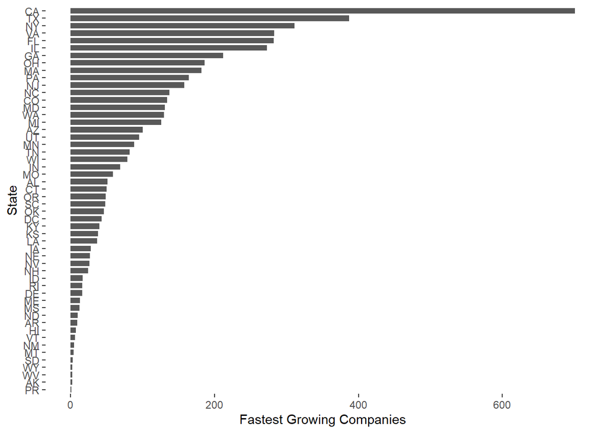

```r
# Answer Question 1 here

inc%>%group_by(State)%>%summarise(Count=n())%>%
  ggplot(aes(x=reorder(State, Count),y=Count))+
  geom_bar(stat="identity", width=.75)+
  coord_flip()+
  guides(fill="none")+
  theme(panel.background = element_blank())+
  ylab("Fastest Growing Companies") +
  xlab("State")
```

## Question 2

Lets dig in on the state with the 3rd most companies in the data set. Imagine you work for the state and are interested in how many people are employed by companies in different industries. Create a plot that shows the average and/or median employment by industry for companies in this state (only use cases with full data, use R’s `complete.cases()` function.) In addition to this, your graph should show how variable the ranges are, and you should deal with outliers.

```r
# Answer Question 2 here

inc%>%group_by(State) %>%
  summarise(Count=n()) %>%
  arrange(desc(Count)) %>%
  mutate(row_number = row_number())%>%
  filter(row_number == 3) %>%
  select(-row_number)
```

```
## # A tibble: 1 x 2
##   State Count
##   <chr> <int>
## 1 NY      311
```

State in question is NY, hence plot will be built using NY as filter. Given outliers in some of the industries, there are two options:  
i: Build a chart using log of Employees. In this case, all large numbers are scaled down. It is a complete chart from a visual standpoint but interpretability is limited.  
ii: Build a chart with an upper limit on the X axis so that visualization is not impaired by some large numbers. Results are easier to understand but because we removed some outliers, chart does not display all numbers.

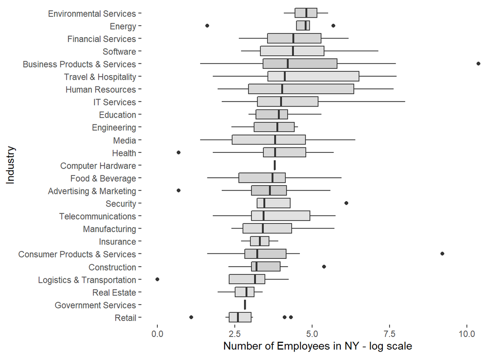

```r
# Answer Question 2 here
# Option 1

inc%>%filter(State == "NY", complete.cases(.)) %>%
   select(Industry, Employees) %>%
   mutate(LogEmployees=log(Employees))%>%
   group_by(Industry)%>%
   ggplot(aes(x=LogEmployees, y=reorder(Industry, LogEmployees, median), fill=Industry))+
   geom_boxplot()+

  scale_fill_grey(start = 0.8, end = 0.89)+
   guides(fill="none")+
   theme(panel.background = element_blank())+
   xlab("Number of Employees in NY - log scale") +
   ylab("Industry")
```

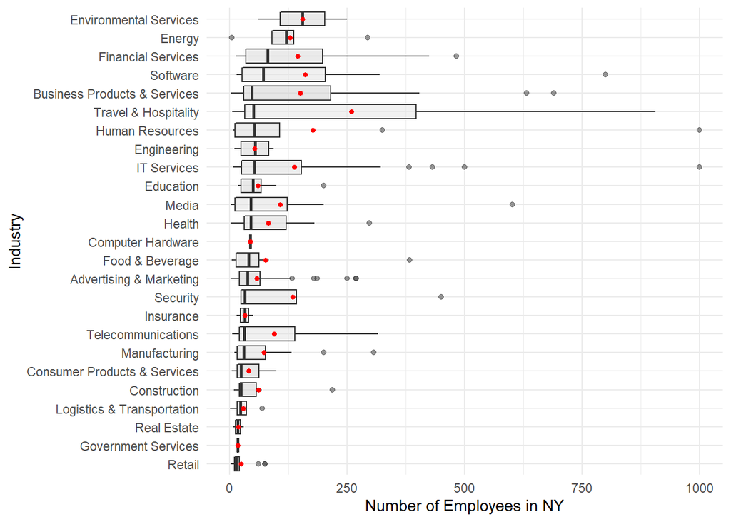

```r
# Answer Question 2 here
# Option 2

inc%>%filter(State == "NY", complete.cases(.)) %>%
  drop_na()%>%
  select(Industry, Employees) %>%
  group_by(Industry)%>%
  ggplot(aes(x=Employees, y=reorder(Industry, Employees, median), fill=Industry))+
  geom_boxplot(alpha=0.5)+
  stat_summary(fun.y=mean, geom="point", shape=20, size=2, color="red", fill="red")+
  xlim(NA, 1000)+
  scale_fill_grey(start = 0.8, end = 0.89)+
  guides(fill="none")+
  theme(panel.background = element_blank())+
  xlab("Number of Employees in NY") +
  ylab("Industry")+
  theme_minimal()
```

## Question 3

Now imagine you work for an investor and want to see which industries generate the most revenue per employee. Create a chart that makes this information clear. Once again, the distribution per industry should be shown.

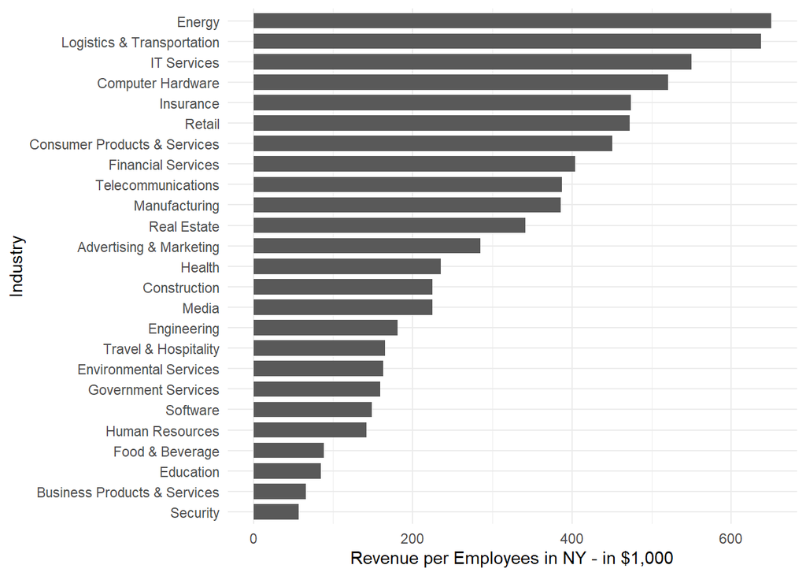

```r
# Answer Question 3 here
inc%>%filter(State == "NY", complete.cases(.)) %>%
  drop_na()%>%
  group_by(Industry)%>%
  summarise(Total_Revenue=(sum(Revenue)/1000)/sum(Employees), .groups = "drop_last")%>%
  ggplot(aes(x=reorder(Industry,Total_Revenue), y=Total_Revenue))+
  geom_bar(stat="identity", width=.75)+
  coord_flip()+
  guides(fill="none")+
  theme(panel.background = element_blank())+
  ylab("Revenue per Employees in NY - in $1,000") +
  xlab("Industry")+
  theme_minimal()
```